# Math 365 / Comp 365: Homework 3

### *Please bring a stapled hard copy of your answers to class*

### Problem 1

In class, we showed how to construct a sequence of unit lower-triangular matrices $\{L_{k}\}_{k=1,2,\ldots,n-1}$ of the form

$$L_{k}=\begin{pmatrix} 1 & & & & & \\
& \ddots & & & & \\
& & 1 & & & \\
& & -\ell_{k+1,k} & 1 & & \\
& & \ddots & & \ddots & \\
& & -\ell_{n,k} & & & 1
\end{pmatrix}~, \hbox{ where } \ell_{j,k}=\frac{A_{j,k}}{A_{k,k}},~\hbox{ for } k\leq j \leq n,$$

such that

$$L_{n-1} L_{n-2} \ldots L_{2} L_{1} A = U,$$

with $U$ being an upper-triangular matrix. We now want to show in two steps that

$$L:= L_{1}^{-1} L_{2}^{-1} \ldots L_{n-2}^{-1} L_{n-1}^{-1}$$

is a unit lower-triangular matrix.

1. Show that

$$L_{k}^{-1} = \begin{pmatrix} 1 & & & & & \\
& \ddots & & & & \\
& & 1 & & & \\
& & \ell_{k+1,k} & 1 & & \\
& & \ddots & & \ddots & \\
& & \ell_{n,k} & & & 1
\end{pmatrix}.$$

**Hint**: Start by showing that $L_k=I-\ell_k e_k^{T}$, where $e_k$ is an $n \times 1$ vector with a 1 in the $k^{th}$ entry, and zeros elsewhere, and

$$\ell_k = \begin{pmatrix} 0 \\ \vdots \\ 0 \\ \ell_{k+1,k} \\ \vdots \\ \ell_{n,k} \end{pmatrix}.$$

We know that if we multiply the vector $\ell_k$ by the vector $e_k^{T}$ we get the $n\times n$ $0$ matrix except for $\ell_k$ in the $k_th$ column. Also, we can conclude that $I-\ell_k e_k^{T}=L_k$, since:
$$L_{k}=\begin{pmatrix} 1 & & & & & \\
& \ddots & & & & \\
& & 1 & & & \\
& & -\ell_{k+1,k} & 1 & & \\
& & \ddots & & \ddots & \\
& & -\ell_{n,k} & & & 1
\end{pmatrix}~, \hbox{ where } \ell_{j,k}=\frac{A_{j,k}}{A_{k,k}},~\hbox{ for } k\leq j \leq n,$$
Further, since we know that $L_k^{-1}L_k=I$, we can conclude that:
$$L_{k}^{-1} = \begin{pmatrix} 1 & & & & & \\
& \ddots & & & & \\
& & 1 & & & \\
& & \ell_{k+1,k} & 1 & & \\
& & \ddots & & \ddots & \\
& & \ell_{n,k} & & & 1
\end{pmatrix}.$$
As this is the matrix that results from performing row operations on $L_k$ augmented with $I$ to get $L_{-1}$.

2. Now show that

$$L:= L_{1}^{-1} L_{2}^{-1} \ldots L_{n-2}^{-1} L_{n-1}^{-1} = \begin{pmatrix} 1 & & & & \\
\ell_{21} & 1 & & & \\
\ell_{31} & \ell_{32} & 1 & & \\
\vdots & \vdots & \ddots & \ddots & \\
\ell_{n1} & \ell_{n2} & \cdots & \ell_{n,n-1} & 1 \\
\end{pmatrix}$$

Because each L is a lower triangular matrix, when we perform matrix multiplication on $L_k^{-1}L_{k+1}^{-1}$ we wind up with the matrix:

$$L_{k*(k+1)}^{-1} = \begin{pmatrix} 1 & & & & & \\
& \ddots & & & & \\
& & 1 & & & \\
& & \ell_{k+1,k} & 1 & & \\
& & \ddots & \ell_{k+1+1,k+1} & \ddots & \\
& & \ell_{n,k} & \ell_{n, k+1}& & 1
\end{pmatrix}.$$

This shows that multiplying the lower triangular $L_k^{-1}$ and $L_{k+1}^{-1}$ matricies does not change the values in either the $k_{th}$ or the $k+1$ columns, proving that the resulting matrix will not change its column values after multiplication. This implies that for all $L= L_{1}^{-1} L_{2}^{-1} \ldots L_{n-2}^{-1} L_{n-1}^{-1}$ the matrix resulting from multiplying out every component matrix is:

$$L= L_{1}^{-1} L_{2}^{-1} \ldots L_{n-2}^{-1} L_{n-1}^{-1} = \begin{pmatrix} 1 & & & & \\
\ell_{21} & 1 & & & \\
\ell_{31} & \ell_{32} & 1 & & \\
\vdots & \vdots & \ddots & \ddots & \\
\ell_{n1} & \ell_{n2} & \cdots & \ell_{n,n-1} & 1 \\
\end{pmatrix}$$

Because the individual column vectors do not change as a result of the multiplication for any two lower triangular matricies. This proves what we set out to prove.

### Problem 2

This was Exercise 2 on Activity A6.

*This problem is from Section 2.5, page 131 of Linear Algebra and Its Applications, by David Lay, the textbook many of you used for MATH 236.*

1. The solution to the approximate steady-state heat flow problem for this plate can be written as a system of linear equations $Ax=b$, where $x=[x_1, x_2, \ldots, x_8]$ is the vector of temperatures at nodes 1 through 8. Find the $8 \times 8$ matrix $A$ and the vector $b$. Hint: $A$ should be a banded matrix with many zeros in the top right and bottom left parts of $A$.

Matrix A can be constructed as:

```r
A = rbind(c(4, -1, -1, 0, 0, 0, 0, 0), c(-1, 4, 0, -1, 0, 0, 0, 0), c(-1, 0, 4, -1, -1, 0, 0, 0), c(0, -1, -1, 4, 0, -1, 0, 0), c(0, 0, -1, 0, 4, -1, -1, 0), c(0, 0, 0, -1, -1, 4, 0, -1), c(0, 0, 0, 0, -1, 0, 4, -1), c(0,0,0,0,0,-1,-1,4))
print(A)
```

```
##      [,1] [,2] [,3] [,4] [,5] [,6] [,7] [,8]
## [1,]    4   -1   -1    0    0    0    0    0
## [2,]   -1    4    0   -1    0    0    0    0
## [3,]   -1    0    4   -1   -1    0    0    0
## [4,]    0   -1   -1    4    0   -1    0    0
## [5,]    0    0   -1    0    4   -1   -1    0
## [6,]    0    0    0   -1   -1    4    0   -1
## [7,]    0    0    0    0   -1    0    4   -1
## [8,]    0    0    0    0    0   -1   -1    4
```

While the vector B we are solving for is:

```r
b = c(5, 15, 0, 10, 0, 10, 20, 30)
print(b)
```

```
## [1]  5 15  0 10  0 10 20 30
```

2. Use your function from Exercise 1 (on the activity) to perform an LU factorization of $A$. Do you notice anything special about the structures of $L$ and $U$?

Here is my LU Function:

```r
myLU = function(A) {
  n = nrow(A)
  U = A
  L = diag(n)
  for(k in 1:(n-1)) {
    for(j in (k+1):n){
      L[j,k] = U[j,k]/U[k,k]
      U[j,k:n] = U[j,k:n]-L[j,k]*U[k,k:n]
    }
  }
  print(nrow(L))
  return(list(L=L,U=U))
}
```

```r
aLU = myLU(A)
```

```
## [1] 8
```

```r
aL = aLU$L
aU = aLU$U
#print(aL)
#print(nrow(aL))
```

3. Once you have an LU factorization for a matrix $A$, you need to do the two-step procedure to complete the back substitution to solve $Ax=b$. Here is code for that:

```r
mySolve=function(L,U,b,tol=1e-10){
  n=nrow(L)

  # First solve Ly=b
  y = rep(0,n)        # pre-allocate a vector y with 0s in it.
  if(abs(L[1,1])<tol) stop('There is a zero on the diagonal of L')
  y[1] = b[1]/L[1,1]  # Fill in the 1st value of y
  for (j in 2:n ) {
    if(abs(L[j,j])<tol) stop('There is a zero on the diagonal of L')
    y[j] = (b[j] - L[j,1:(j-1)]%*%y[1:(j-1)])/L[j,j]
  }

  # Then solve Ux=y
  x = rep(0,n)        # pre-allocate a vector x with 0s in it.
  if(abs(U[n,n])<tol) stop('There is a zero on the diagonal of U')
  x[n] = y[n]/U[n,n]  # Fill in the nth value of x
  for (j in (n-1):1 ) {
    if(abs(U[j,j])<tol) stop('There is a zero on the diagonal of U')
    x[j] = (y[j] - U[j,(j+1):n]%*%x[(j+1):n])/U[j,j]
  }
  return(x)
}
```

Make sure you understand what the code is doing, and then use it to find the steady-state temperatures at nodes 1 through 8.

```r
xvec = mySolve(aL, aU, b)
print(xvec)
```

```
## [1]  3.956938  6.588517  4.239234  7.397129  5.602871  8.760766  9.411483
## [8] 12.043062
```

4. The temperature on the right-hand side of the plate was measured incorrectly. It is actually 30 degrees. Find the new steady-state temperatures. Hint: you should not do another LU factorization!

To do this all we need to do is backsolve for a new b vector, b2. Where b2 is:

```r
b2 = c(5, 15, 0, 10, 0, 10, 0, 10, 30, 40)
```

So the new x2vec should be:

```r
x2vec = mySolve(aL, aU, b2)
print(x2vec)
```

```
## [1] 3.593301 6.224880 3.148325 6.306220 2.693780 5.851675 1.775120 4.406699
```

5. Use the R function `solve(A)` to compute $A^{-1}$. Note that $A^{-1}$ is a **dense** matrix (without many zeros). When $A$ is large, $L$ and $U$ can be stored in much less space than $A^{-1}$. This fact is another reason for preferring the LU factorization of $A$ to $A^{-1}$ itself.

```r
Ainv = solve(A)
print(Ainv)
```

```
##             [,1]        [,2]       [,3]       [,4]       [,5]       [,6]
## [1,] 0.295264808 0.086553374 0.09450586 0.05094869 0.03180993 0.02273552
## [2,] 0.086553374 0.295264808 0.05094869 0.09450586 0.02273552 0.03180993
## [3,] 0.094505857 0.050948688 0.32707474 0.10928890 0.10450421 0.05913216
## [4,] 0.050948688 0.094505857 0.10928890 0.32707474 0.05913216 0.10450421
## [5,] 0.031809932 0.022735522 0.10450421 0.05913216 0.32707474 0.10928890
## [6,] 0.022735522 0.031809932 0.05913216 0.10450421 0.10928890 0.32707474
## [7,] 0.009998350 0.008183468 0.03180993 0.02273552 0.09450586 0.05094869
## [8,] 0.008183468 0.009998350 0.02273552 0.03180993 0.05094869 0.09450586
##             [,7]        [,8]
## [1,] 0.009998350 0.008183468
## [2,] 0.008183468 0.009998350
## [3,] 0.031809932 0.022735522
## [4,] 0.022735522 0.031809932
## [5,] 0.094505857 0.050948688
## [6,] 0.050948688 0.094505857
## [7,] 0.295264808 0.086553374
## [8,] 0.086553374 0.295264808
```

### Problem 3

*This problem is taken from the in-class portion of an old midterm.*

You are trying to solve a linear system of four equations:

$$\left[\begin{array}{ccc} && \\ & A & \\ && \\ && \end{array}\right]
\left[\begin{array}{c}x_1 \\ x_2 \\ x_3 \\ x_4 \end{array}\right]=\left[\begin{array}{c}3 \\ -2 \\ 4 \\ 2.25 \end{array}\right]~,$$
but unfortunately $A$ is a black box and you cannot see the contents. Oh my! Luckily, from the physics of the problem, you do have three pieces of information about the system and the solution:

- $||x||_{\infty}=2$
- The condition number of $A$, using the $\infty$-norm, is 32
- $\left[\begin{array}{ccc} && \\ & A & \\ && \\ && \end{array}\right] \left[\begin{array}{r}2.0750 \\ 0.1625 \\ 0.4500 \\ -0.1875 \end{array}\right]=\left[\begin{array}{c}3 \\ -2 \\ 4 \\ 2.1875 \end{array}\right]$

Is this information enough to determine the solution $x$ to $Ax=b$? If yes, find $x$. If no, say as much as you can about $x$.

NOTE: All norms used to calculate this problem are infinity norms.

This is not enough information to actually solve for $x$. However, with this information we can say a lot about the composition of our vector $x$.

First, we know that the following equation holds true:

$$RFE\leq cond(A)*RBE$$

And we know the $RBE$ is (using infinity norms):

This implies that the largest value of $x-x_a \leq 1$ (using infinity norm), which implies that the largest value in $x_a$ must be within $1$ away from $2$, the largest value of $x$. From this we can conclude that $x_1=2$, because it is the only point in the vector $x_a$ that is within $1$ unit away from $2$. Further, we can conclude that every $x_i$ value must be within $1$ unit away from its corresponding $x_{ai}$ value.

### Problem 4

A real $n \times n$ matrix $Q$ is *orthonormal* if

$$Q^{T}Q=QQ^T=I;~i.e., Q^{-1}=Q^T.$$

Note: sometimes you will see these matrices just called *orthogonal matrices*. The analagous matrices that contain complex entries ($Q^*Q=QQ^*=I$, where the $~^*$ is a conjugate transpose) are called *unitary*.

Show that $||Q||_2=||Q^{-1}||_2=1$, and therefore the 2-norm condition number of any orthonormal matrix $Q$ is $\kappa_2(Q)=||Q||_2 ||Q^{-1}||_2=1$.

We know that $||Q||_2 = \sqrt{max\{eigenvalue(QQ^T)\}}$ and that $Q^T=Q^{-1}\rightarrow QQ^{-1}=I$. $\rightarrow ||Q||_2 = \sqrt{max\{eigenvalue(I)\}}=1$. And since $Q^{-1}=Q^T$ then $||Q^{-1}||=||Q^T||$. $\rightarrow ||Q^T||_2 = \sqrt{max\{eigenvalue(QQ^T)\}}=1$. $||Q||_2=||Q^{-1}||_2=1 \square$.

### Problem 5

This problem has 3 parts.

1. Modify my `UnitCircleMap` function, which shows the image of the unit ball under a linear mapping $A$ and computes the matrix norm of $A$. We want to let the user choose the norm to be 1, 2, or $\infty$ (“I”). The code is below, and there are a few places where you need to insert a few lines.

```r
UnitCircleMap = function(A,p=2) {

  if (p==2) {
    t = seq(0,2*pi,len=1000)
    x = cos(t)
    y = sin(t)
    nn=norm(A,type="2")
    ni=as.character(p)
  }
  else if (p==1){
    # Insert some code here
    t1 = seq(-1, 0, len=250)
    x1 = t1
    y1 = -1 - t1
    x2 = x1
    y2 = -1*y1
    t2 = seq(0, 1, len=250)
    x3 = t2
    y3 = 1 - t2
    x4 = x3
    y4 = -1*y3
    x = c(x1, x2, x3, x4)
    y = c(y1, y2, y3, y4)
    nn=norm(A,type="1")
    ni=as.character(p)
  }
  else if (p=="I"){
    # Insert some code here
    t1 = seq(-1, 1, len=250)
    x1 = t1
    y1 = rep(1, 250)
    t2 = seq(1, -1, len=250)
    x2 = rep(1, 250)
    y2 = t2
    x3 = t2
    y3 = rep(-1, 250)
    x4 = y3
    y4 = x1
    x = c(x1, x2, x3, x4)
    y = c(y1, y2, y3, y4)
    nn=norm(A,type="I")
    ni="Inf"
  }

  pts = A %*% t(cbind(x,y))

  newx = pts[1,]
  newy = pts[2,]

  M = max(c(newx,newy,1.5))
  m = min(c(newx,newy,-1.5))

  plot(x,y,type='l',col='black',xlim=c(m,M),ylim=c(m,M),xlab="x1",ylab="x2")
  lines(newx,newy,col='red')

  normSize=sprintf("||A||_%s = %1.2f",ni,nn)
  text(-.7*M,.9*M,normSize)
}
```

Here is an example of how the function should be called, and the output it should display. In this case, $A=\begin{bmatrix}1 & 2 \\ 0 & 2\end{bmatrix}$. Once you’ve filled in the missing lines of the function, you can also test your code on this $A$ with the 1 norm and $\infty$-norm.

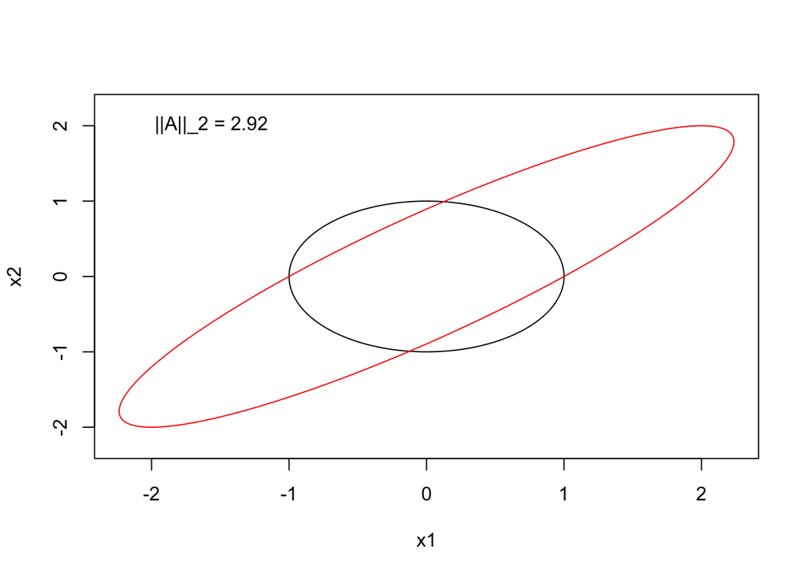

```r
A=cbind(c(1,0),c(2,2))
UnitCircleMap(A,p=2)
```

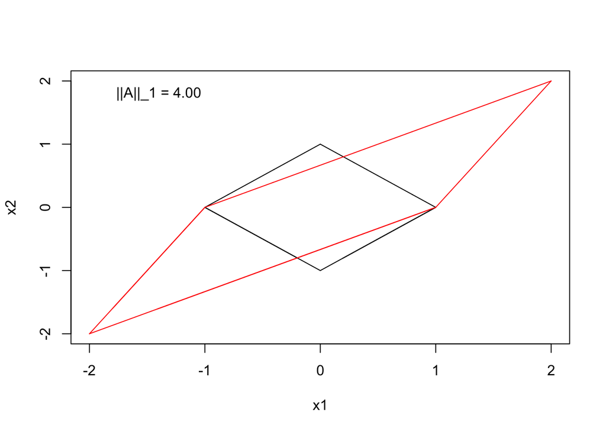

```r
UnitCircleMap(A, p=1)
```

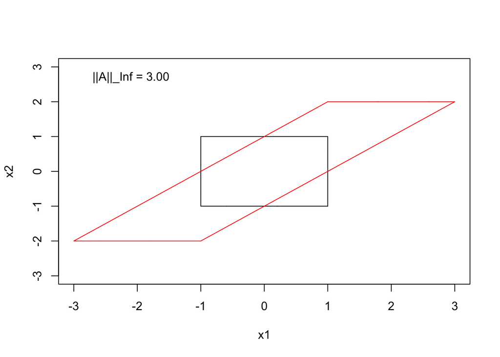

```r
UnitCircleMap(A, p="I")
```

2. Compute the condition number of the matrix $A$ above (using the $p=1,2, \infty$-norms). Visually explain why the condition number for each $p$ is the value you found.

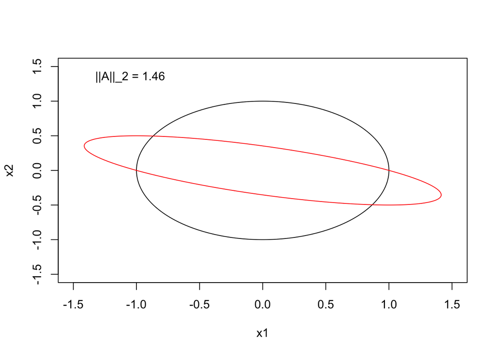

```r
Cond = function(A,p=2) {
  if (p == 2) {  # by default use the
    s = svd(A)$d
    s = s[s>0]
    return(max(s)/min(s))
  }
  if (p == 1) {  # use the 1 norm
    Ainv = solve(A)
    return(max(colSums(abs(A)))*max(colSums(abs(Ainv))))
  }
  if (p == 'I') {   # use the infinity norm
    Ainv = solve(A)
    return(max(rowSums(abs(A)))*max(rowSums(abs(Ainv))))
  }
}

Ainv = solve(A)
UnitCircleMap(Ainv,p=2)
```

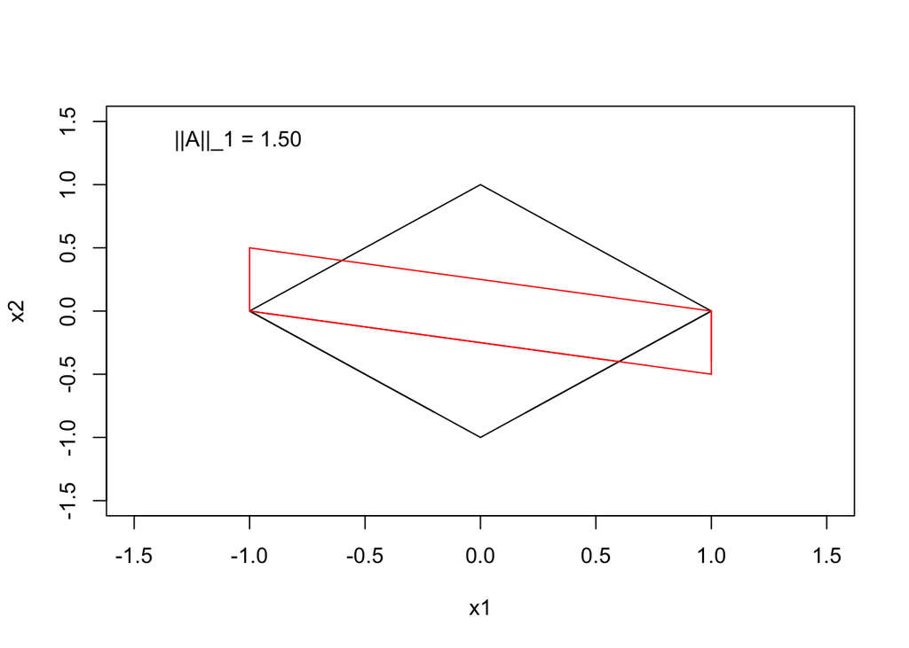

```r
UnitCircleMap(Ainv, p=1)
```

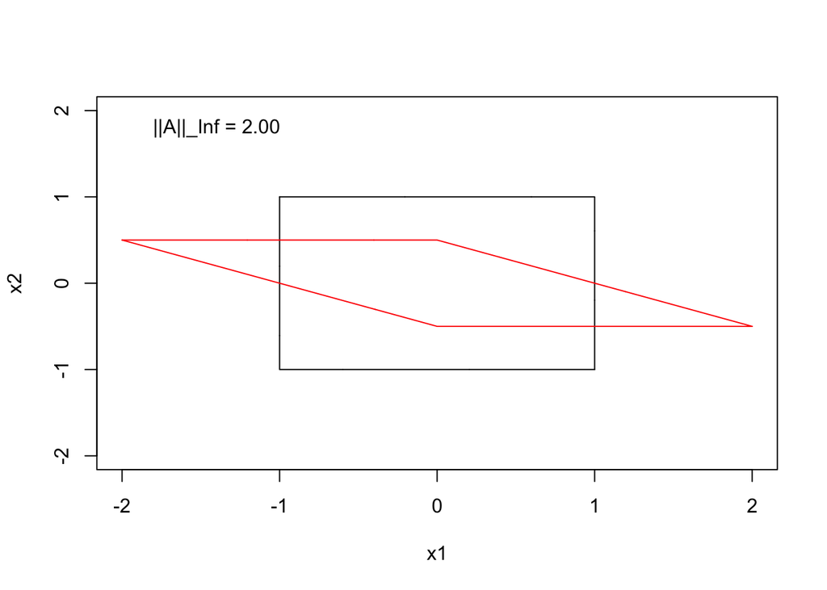

```r
UnitCircleMap(Ainv, p="I")
```

```r
c1 = Cond(A, p=1)
c2 = Cond(A, p=2)
cinf = Cond(A, p="I")

print(c1)
```

```
## [1] 6
```

```r
print(c2)
```

```
## [1] 4.265564
```

```r
print(cinf)
```

```
## [1] 6
```

3. Use your code to determine whether $||Q||_1=||Q||_{\infty}=||Q||_2=1$ for all orthonormal matrices $Q$.

**Hint**: Try $Q=\begin{pmatrix} \frac{1}{\sqrt{2}} & \frac{-1}{\sqrt{2}} \\ \frac{1}{\sqrt{2}} & \frac{1}{\sqrt{2}} \end{pmatrix}$, which is a rotation matrix that rotates vectors counter-clockwise by $\frac{\pi}{4}$.

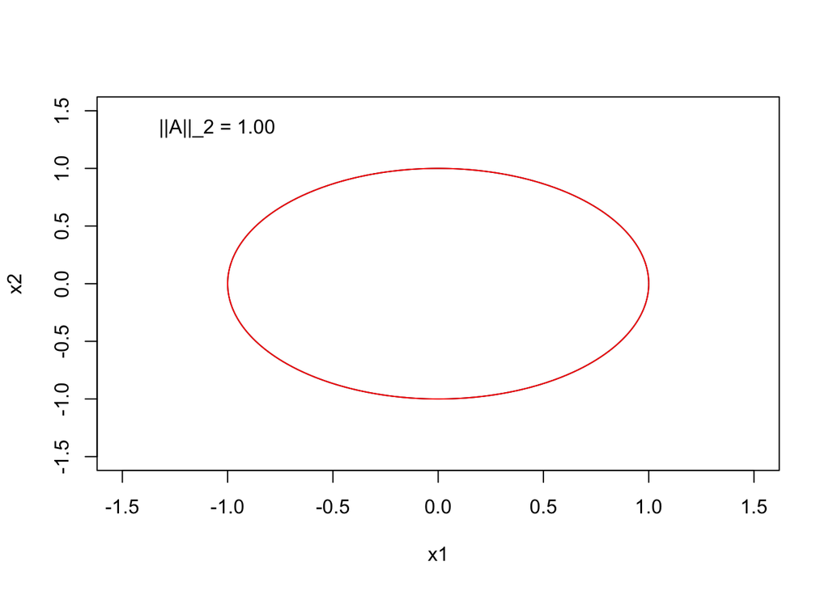

```r
Q = cbind(c(1/sqrt(2),1/sqrt(2)), c(-1/sqrt(2), 1/sqrt(2)))
UnitCircleMap(Q,p=2)
```

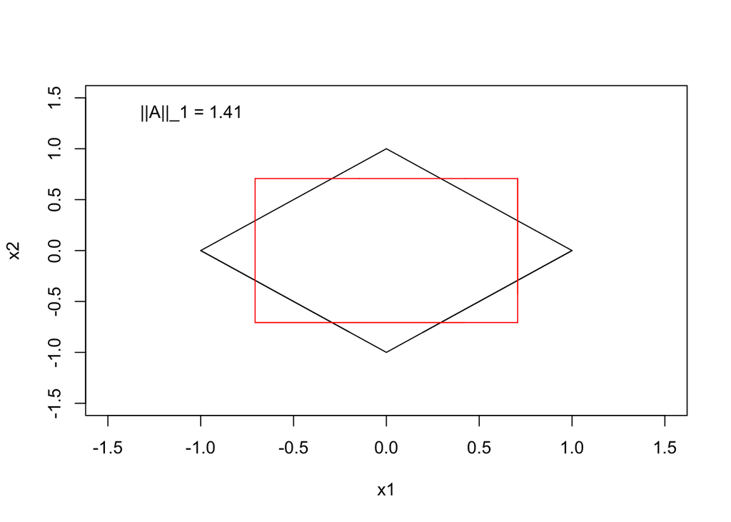

```r
UnitCircleMap(Q, p=1)
```

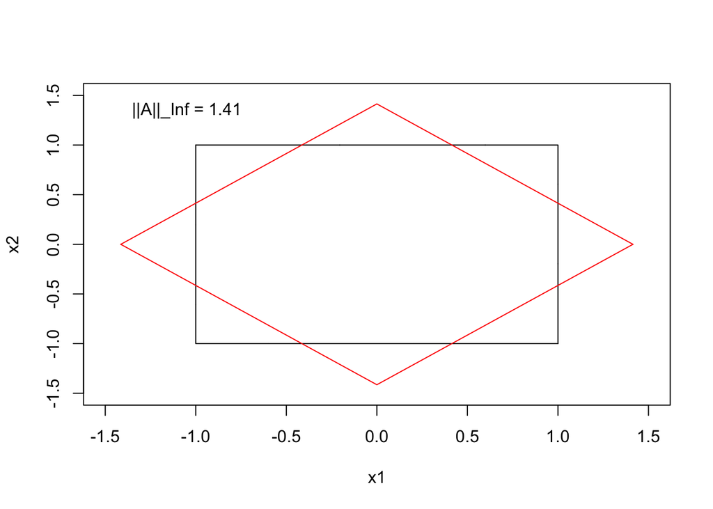

```r
UnitCircleMap(Q, p="I")
```

From the above images it is clear that for any orthonormal matrix Q, the statement $||Q||_1=||Q||_{\infty}=||Q||_2=1$ is false because while $||Q||_2=1$, $||Q||_2\neq||Q||_{\infty}$ and $||Q||_2\neq||Q||_1$. Further, neither $||Q||_1$ nor $||Q||_{\infty}$ equal 1. This proves that the statement $||Q||_1=||Q||_{\infty}=||Q||_2=1$ is not true for all orthonormal matricies $Q$.

### Problem 6

This was Exercise 3 on Activity A7.

Prove that
$$||A||_{\infty}=\max_{1 \leq i \leq n}\left\{ \sum_{j=1}^n |A_{ij}| \right\}=\text{maximum absolute row sum}.$$

For the left hand side:

$$||A||_{\infty} = \max_{x \neq 0} \frac{||Ax||_{\infty}}{||x||_{\infty}}$$
Where $||Ax||_{\infty}$ is the vector containing the linear combination of the rows of A.

Now we can conclude that:

$$||A||_{\infty} \leq \max_{x \neq 0} ||b||_{\infty}$$

Where $b$ represents the vector resulting from normalizing $||Ax||_{\infty}$ by $||x||_{\infty}$. This implies that $||A||_{\infty}$ must be less than or equal to the maximum value $||b||_{\infty}$, where the vector b contains the row sums of A. This means that $||A||_{\infty}$ must be less than or equal to the maximum absolute row sum of A.

For the right hand side:

If we substitute out $\frac{||Ax||_{\infty}}{||x||_{\infty}}$ again for $A$ we can say that:

$$\frac{||Ax||_{\infty}}{||x||_{\infty}} \geq \max_{1 \leq i \leq n}\left\{ \sum_{j=1}^n |A_{ij}| \right\}$$

However, if we look at the summation on the right side of the equation we see that it sums absolute value for every $j_{th}$ column in $A$ for every $i_{th}$ row in A. From these row sums, it finds the maximum sum that occurs at some arbitrary row $k$, and returns that. We then get that:

$$\frac{||Ax||_{\infty}}{||x||_{\infty}} \geq k$$

Where $k$ is the maximum absolute row sum of A. However, on the LHS we proved that:

$$||A||_{\infty} \leq \max_{x \neq 0} ||b||_{\infty}$$

Where
$$b$$
is the vector containing the maximum absolute row sums of A. Thus we have proved that $||A||_{\infty}$ is both less than or equal to the absoulte row sum of A and greater than or equal to the absolute row sum of A. Thus we can conclude that:

$$||A||_{\infty}=\max_{1 \leq i \leq n}\left\{ \sum_{j=1}^n |A_{ij}| \right\}=\text{maximum absolute row sum}.$$

Is a true statement.

### Problem 7

Solve the following system by finding the $PA=LU$ factorization and then carrying out the two-step back substitution (all by hand):

$$A=\begin{pmatrix}-1 & 0 & 1 \\
3 & 1 & 1 \\
2 & 0 & 1
\end{pmatrix} \begin{pmatrix} x_1 \\ x_2\\ x_3\end{pmatrix}=\begin{pmatrix} 2 \\ 5 \\ 5 \end{pmatrix}.$$

For the first step of the factorization:

$$A1=\begin{pmatrix}3 & 1 & 1 \\
0 & \frac{1}{3} & \frac{4}{3} \\
0 & \frac{-2}{3} & \frac{1}{3}
\end{pmatrix}$$

$$P1=\begin{pmatrix}0 & 1 & 0 \\
1 & 0 & 0 \\
0 & 0 & 1
\end{pmatrix}$$

$$L1=\begin{pmatrix}1 & 0 & 0 \\
\frac{-1}{3} & 1 & 0 \\
\frac{2}{3} & 0 & 1
\end{pmatrix}$$

And after one more step we get the final PA = LU Factorization of:

$$P=\begin{pmatrix}0 & 1 & 0 \\
0 & 0 & 1 \\
1 & 0 & 0
\end{pmatrix}$$

$$A=\begin{pmatrix}-1 & 0 & 1 \\
3 & 1 & 1 \\
2 & 0 & 1
\end{pmatrix}$$

$$L=\begin{pmatrix}1 & 0 & 0 \\
\frac{2}{3} & 1 & 0 \\
\frac{-1}{3} & \frac{-1}{2} & 1
\end{pmatrix}$$

$$U=\begin{pmatrix}3 & 1 & 1 \\
0 & \frac{-2}{3} & \frac{1}{3} \\
0 & 0 & \frac{3}{2}
\end{pmatrix}$$

Or that
$$Ly=\begin{pmatrix} 2 \\ \frac{11}{3} \\ \frac{15}{2}\end{pmatrix}.$$

And then to solve
$$Ux=b$$
:

$$Ux=\begin{pmatrix}3 & 1 & 1 \\
0 & \frac{-2}{3} & \frac{1}{3} \\
0 & 0 & \frac{3}{2}
\end{pmatrix} \begin{pmatrix} x_1 \\ x_2\\ x_3\end{pmatrix}=\begin{pmatrix} 2 \\ \frac{11}{3} \\ \frac{15}{2} \end{pmatrix}.$$

Or that
$$Ly=\begin{pmatrix} 0 \\ -3 \\ 5\end{pmatrix}.$$